**Registration Guideline for POSCO Project**

By JongHwan Lee  
http://iai.postech.ac.kr/  
Industrial AI Lab. at POSTECH  
최종 수정일: 2020.03.04

Table of Contents

# 1. 연구계획서 작성

- POSCO 과제 연구계획서 Form이 존재하기에 Form에 맞추어서 작성해야 함.
  - *하기의 Dropbox 경로에서 최종본 샘플 참고
  - (Dropbox 경로: Dropbox\04_iAI_lab\05_project\POSCO\2020\열연 바상향\연구계획서 관련)
- 연구계획서 구성은 다음과 같음.
  - 연구계획 총괄표
  - 연구개발 추진계획
  - 선행특허조사
  - 연구비 내역서
- **여기서 가장 중요한 부분은 연구계획 총괄표와 연구비 내역서**
  - 연구계획 총괄표 부분은 Counter part에서 제시해주더라도, 재확인 필요.
  - 연구비 내역서에서 견적서가 필요한 부분은 견적서를 기준으로 작성해야 함.
    - (연구비 내역서의 금액과 견적서의 금액과 동일해야 함.)

# 2. POSCO 기술 연구원 Page Log-in

POSCO 기술 연구원 주소: http://www.steel-n.com/lab/ (Internet Explorer를 사용하는 것을 추천함)

**1. 위의 주소에 접속하면 LOGIN 부분은 다음과 같음.**

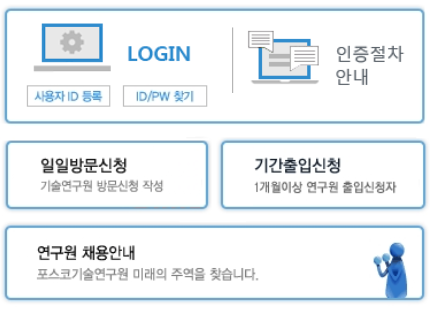

**2. 인증서가 없기 때문에, LOGIN 부분을 누면 아래와 같이 오류가 발생함.**

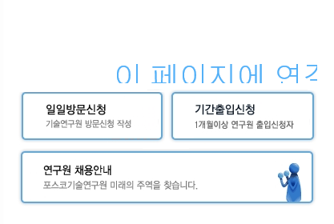

- 인증서는 Dropbox에 공유함.
  - Dropbox\04_iAI_lab\05_project\POSCO\2020\열연 바상향 (인증서 Name: certpostech )
  - 인증서를 다운로드 한 후, 아래의 순서로 인증서를 가져오면 됨.
- 인증서 가져오는 순서  
  1) Explorer 상단에 위치한 도구  
  2) 인터넷 옵션 $\rightarrow$ 내용 $\rightarrow$ 인증서  
  3) 가져오기 클릭 (인증서를 클릭하면 새로운 창이 뜸)  
  4) 다음 클릭 후, 가져올 파일에 위에서 다운로드 한 인증서 선택. (인증서가 보이지 않을시, 파일 유형을 모든 파일로 바꾸면 선택됨)  
  5) **인증서 비밀번호 (postech)** 기입 후, 기본으로 설정된 옵션을 변경하지 않고 계속 다음 진행  
  *상기와 같은 방법으로 인증서를 성공적으로 가져와도, Error가 발생할 수 있음. 이때는 포스코ICT 이철희 담당자님에게 문의(054-220-5931)

**3. 다시 LOGIN 부분을 누르면, 아래와 같이 ID 및 Password 창이 생김**

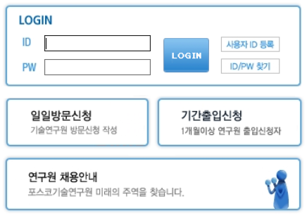

**4. 교수님 계정 입력(ID: YC100925, PASSWORD: 이혜령 선생님에게 문의)**

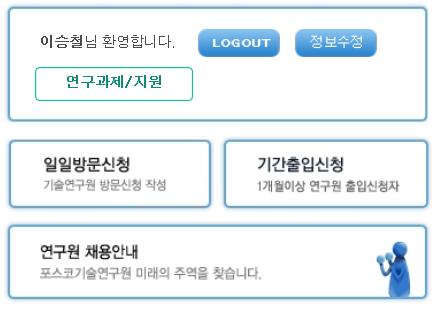

- ID/PASSWORD가 틀리는 경우 해결방법  
  이혜령 선생님이 변경하신 게 아니라면, ID/PW 찾기로 PW 초기화 가능 $\rightarrow$ 초기화된 PW는 입력한 교수님 메일로 발송

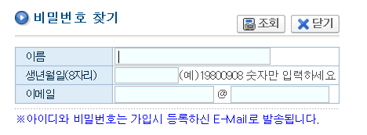

**5. 연구과제/지원 클릭**

# 3. System 상의 과제 항목 채우기

**1. 연구과제/지원 클릭하면, 아래와 같은 창이 생김.**

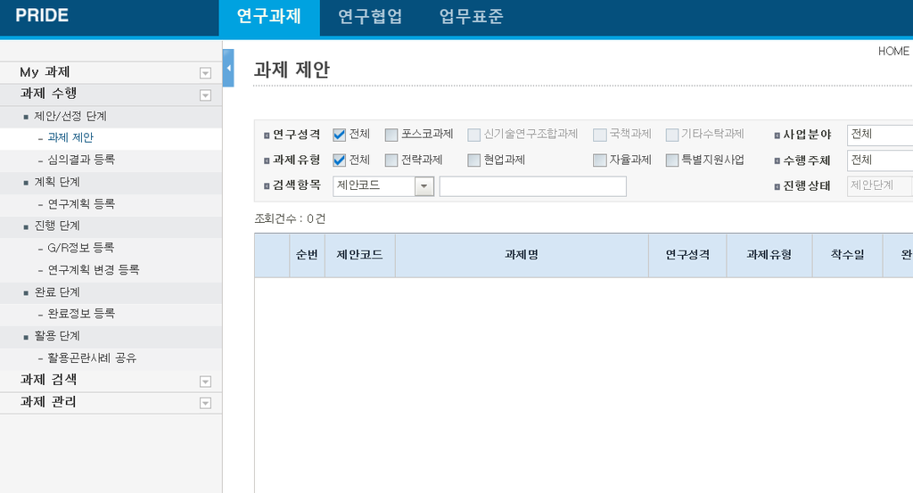

**2. 왼쪽 상단의 연구계획 등록 클릭 후, 제안되어 있는 과제 클릭하면 아래와 같은 창이 생김. (제안은 Counter part가 해놓음.)**

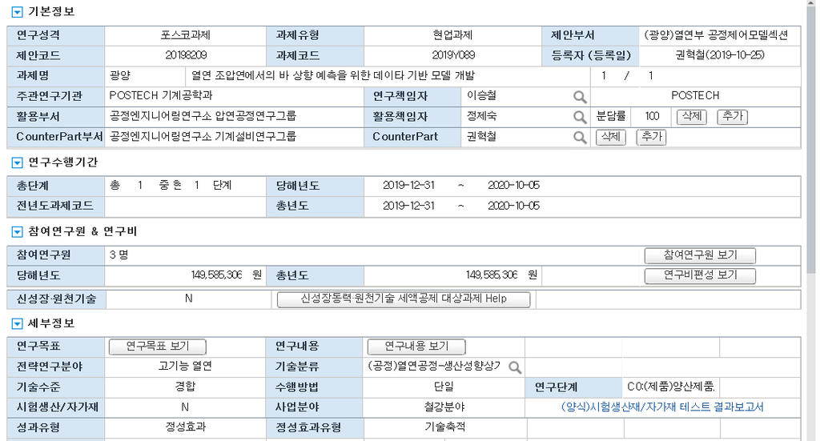

**3. 필요 항목 기입**

- 필요 항목 기입 예시 (Box를 클릭 후, 해당 내용 기입)

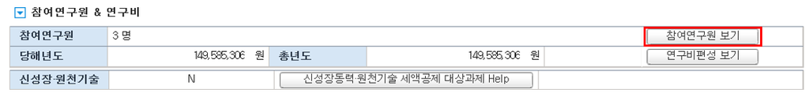

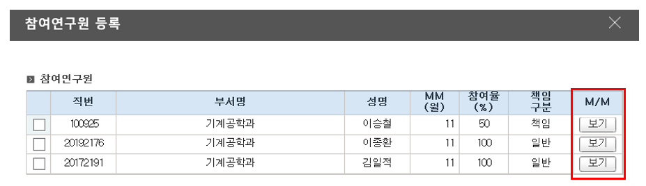

**4. 간접비/인건비 특성**

1) 연구책임자 (교수님) 의 인건비는 100% 간접비로 흡수  
2) 제경비는 100% 간접비로 흡수  
$\;\;\;$총 인건비 (교수님 + 학생) 의 89%로 계산. 단, 비율은 매년 변동되므로 이혜령 선생님에게 학인이 필요함.  
3) 기술개발비의 50%는 간접비로 흡수  
$\;\;\;$총 인건비 *제경비* 5%로 계산

4) 과제 종료 후 잔액  
$\;\;\;$인건비 잔액의 80%만 적립 가능 (인건비 잔액 20% 간접비로 흡수)  
$\;\;\;$직접비 및 기술개발비 잔액은 100% 간접비로 흡수

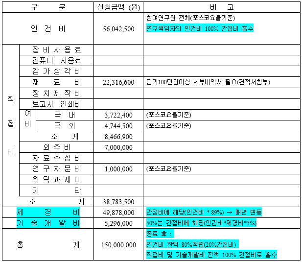

- 자세한 내용은 Dropbox에 공유함.
  - D:\Dropbox\01_POSTECH\04_iAI_lab\01_lab_admin\iAI guidelines\posco_registration_guideline\
  - (File Name : 연구비 작성 예시, 2020년 연구비 요율 (포스코) )

# 4. 전송 요청

1) 연구계획서 업로드는 맨 마지막에 수행

2) 전송 요청 클릭 $\rightarrow$ 기입해야 할 항목들이 경고창으로 나옴.

$\;\;\;$(경고창을 보면서 기입해야 할 항목들 Check 가능.)

$\;\;\;$(단, 연구계획서 업로드를 한 상태라면 바로 전송이 될 수 있으니 주의)

# 5. 부서 담당자

1) 포스코 시스템 Error 발생 담당자

- 이철희 담당자님 (포스코 ICT, 054-220-5931)

2) 포항공대 연구비 최종 검토 담당자

- 오복주 선생님: 연구지원팀, 054-279-3637, hera@postech.ac.kr
- 이지영 선생님 (오복주 선생님 대리): 연구지원팀, 054-279-2574, yiji11@postech.ac.kr

```python
%%javascript
$.getScript('https://kmahelona.github.io/ipython_notebook_goodies/ipython_notebook_toc.js')
```